# Uso de la API del Covid19 con Pandas

## Origen de los datos

En esta práctica, se va a usar la API [COVID-19](https://api.covid19api.com/countries), desarrollada por Kyle Redelinghuys y basada en [los datos](https://github.com/CSSEGISandData/COVID-19) que proporciona la [Universidad Johns Hopkins](https://systems.jhu.edu/research/public-health/ncov/).

### Instalación de las librerías con las que se va a trabajar

En primer lugar, es necesario instalar la librería para proyectar los datos que se obtengan sobre la incidencia de la COVID-19. Para ello, se emplea el comando `pip install pandas`. Pandas es una librería estándar de Python que se encarga del manejo de datos. Para especificar que lo que se está realizando es ejecutar un comando bash, se indica con el signo `!` al inicio de la línea.

A continuación, se instala Pandas con el siguiente comando:

```python
!pip install pandas
```

### Configuración de Pandas

Tras este paso, se importa el proyecto. Para ello, se utiliza la función `import` y se importa la librería Pandas como `pd`, de forma abreviada, tal y como sigue a continuación.

```python
import pandas as pd
```

### Creación de la variable

Ya se ha instalado la librería Pandas y se ha importado. Ahora se comienza con la creación de las variables necesarias para, posteriormente, realizar los gráficos con los datos de la API. Primero se define la variable `url`, que será la que le diga a Python el origen de los datos:

```python
 url = 'https://api.covid19api.com/countries'
```

### Creación de DataFrame

Cuando se tiene el enlace donde se encuentran los datos, los mostramos. Primero se crea un DataFrame (una tabla con filas y columnas en la que aparecerán los datos). Para ello, se utiliza la función de Pandas que lee el formato `.json`, en el que están los datos de la API: `pd.read_json(url)`. Al poner `(url)`, se le señala a Pandas cuáles son los datos que tiene que leer.

```python
df = pd.read_json(url)
```

Se ejecuta el `df` para visualizar que todo está correcto:

```python
df
```

|  | Country | Slug | ISO2 |
| --- | --- | --- | --- |
| 0 | French Polynesia | french-polynesia | PF |
| 1 | Indonesia | indonesia | ID |
| 2 | Malta | malta | MT |
| 3 | Sao Tome and Principe | sao-tome-and-principe | ST |
| 4 | Haiti | haiti | HT |
| ... | ... | ... | ... |
| 243 | Myanmar | myanmar | MM |
| 244 | Turkey | turkey | TR |
| 245 | Western Sahara | western-sahara | EH |
| 246 | Pitcairn | pitcairn | PN |
| 247 | Tanzania, United Republic of | tanzania | TZ |

248 rows × 3 columns

### Exploración de la tabla

Como se observa, al componerse de 248 filas, solo se muestra un extracto, las primeras y las últimas filas. A continuación, se sigue explorando la tabla.

Por ejemplo, se van a visualizar las 6 primeras filas. Para ello, a través de `head`, se le dice que muestre el DataFrame con las X primeras filas, que en este caso se ha indicado que sean 6:

```python
df.head(6)
```

[output not shown]

```python
df.info()
```

```
<class 'pandas.core.frame.DataFrame'>
RangeIndex: 248 entries, 0 to 247
Data columns (total 3 columns):
 #   Column   Non-Null Count  Dtype
---  ------   --------------  -----
 0   Country  248 non-null    object
 1   Slug     248 non-null    object
 2   ISO2     248 non-null    object
dtypes: object(3)
memory usage: 5.9+ KB
```

Si se quieren conocer más datos técnicos acerca de la composición de lo que se está usando, se puede usar `info`. Esto indica información sobre el DataFrame entre la que incluye el índice (RangeIndex) con el número de entradas, el número de columnas que hay (Data Columns), el nombre de las columnas (Colum), la cantidad de datos nulos que posee la tabla (Non-Null Count), el tipo de variable de las columnas (Dtype) y el tamaño (memory usage).

```python
df.tail(2)
```

|  | Country | Slug | ISO2 |
| --- | --- | --- | --- |
| 246 | Pitcairn | pitcairn | PN |
| 247 | Tanzania, United Republic of | tanzania | TZ |

Si se quiere filtrar por columnas para ver los datos de alguna en particular, se sigue utilizando `df` pero ahora, entre corchetes, se pone el nombre de la columna que se quiera visualizar. Por ejemplo, para ver una lista (abreviada) de países, se emplea 'Country'.

A continuación, se muestra la columna 'Country':

```python
df['Country']
```

```
0                  French Polynesia
1                         Indonesia
2                             Malta
3             Sao Tome and Principe
4                             Haiti
                   ...
243                         Myanmar
244                          Turkey
245                  Western Sahara
246                        Pitcairn
247    Tanzania, United Republic of
Name: Country, Length: 248, dtype: object
```

Además de esto, también se pueden cruzar filas con columnas. Es decir, saber qué valor tiene la fila X en la columna Y. Para ello, se incluye otro corchete a los que se tiene especificando el número de la fila. En este caso, se quiere saber qué país está codificado en la fila número 66 de la tabla o DataFrame.

Se muestra la columna 'Country' y la fila número 66:

```python
df['Country'][66]
```

```
'Somalia'
```

### Tiempo real

https://api.covid19api.com/country/spain/status/confirmed/live

Una vez se han testeado algunas formas de visualización del DataFrame de los países, se centra en algunos territorios concretos para ver su evolución en tiempo real de los casos confirmados.

Para hacer esto, se tiene que definir de nuevo el enlace desde el que Pandas leerá los datos y crear, a partir de este, el DataFrame. En esta ocasión, se observarán los datos de España, por lo que se obtienen desde la API los casos confirmados en tiempo real para el país y se definen. Posteriormente, se muestran para ver que todo ha ido bien.

```python
url_es = 'https://api.covid19api.com/country/spain/status/confirmed/live'
df_es = pd.read_json(url_es)
df_es
```

[output not shown]

Al igual que se realizó anteriormente, se observan diferentes datos de la tabla. Para empezar, se listan las columnas existentes para saber qué datos contiene cada una. Esto se realiza mostrando el DataFrame de España y añadiendo `columns`.

Se muestran los nombres de las columnas de la tabla:

```python
df_es.columns
```

```
Index(['Country', 'CountryCode', 'Province', 'City', 'CityCode', 'Lat', 'Lon',
       'Cases', 'Status', 'Date'],
      dtype='object')
```

De la misma manera, se pueden cruzar filas con las columnas para saber un dato concreto. Por ejemplo, para saber cuál es el dato que se encuentra en la primera fila, empezando por el principio, se filtra por la columna `'Date'`, y con `.head(x)` se indica el número que se quiere ver.

Se muestra la primera fila (1) por la cabecera (head) de la columna 'Date' de la tabla:

```python
df_es['Date'].head(1)
```

```
0   2020-01-22 00:00:00+00:00
Name: Date, dtype: datetime64[ns, UTC]
```

Se muestra la primera fila (1) por el final de la tabla (tail) de la columna 'Date' de la tabla:

```python
df_es['Date'].tail(1)
```

```
802   2022-04-03 00:00:00+00:00
Name: Date, dtype: datetime64[ns, UTC]
```

Se utiliza `info` para exponer información sobre el DataFrame entre la que incluye el índice (RangeIndex) con el número de entradas, el número de columnas que hay (Data Columns), el nombre de las columnas (Colum), la cantidad de datos nulos que posee la tabla (Non-Null Count), el tipo de variable de las columnas (Dtype) y el tamaño (memory usage).

```python
df_es.info()
```

```
<class 'pandas.core.frame.DataFrame'>
RangeIndex: 803 entries, 0 to 802
Data columns (total 10 columns):
 #   Column       Non-Null Count  Dtype
---  ------       --------------  -----
 0   Country      803 non-null    object
 1   CountryCode  803 non-null    object
 2   Province     803 non-null    object
 3   City         803 non-null    object
 4   CityCode     803 non-null    object
 5   Lat          803 non-null    float64
 6   Lon          803 non-null    float64
 7   Cases        803 non-null    int64
 8   Status       803 non-null    object
 9   Date         803 non-null    datetime64[ns, UTC]
dtypes: datetime64[ns, UTC](1), float64(2), int64(1), object(6)
memory usage: 62.9+ KB
```

Si se profundiza en cuestiones estadísticas, se pueden conocer, por ejemplo, datos como la media, la desviación estándar, los diferentes cuartiles y el valor mínimo y máximo. Para ello, se emplea `describe`.

Muestra variables estadísticas de la tabla (de las columnas numéricas):

```python
df_es.describe()
```

|  | Lat | Lon | Cases |
| --- | --- | --- | --- |
| count | 8.030000e+02 | 803.00 | 8.030000e+02 |
| mean | 4.046000e+01 | -3.75 | 3.242248e+06 |
| std | 7.109856e-15 | 0.00 | 3.109442e+06 |
| min | 4.046000e+01 | -3.75 | 0.000000e+00 |
| 25% | 4.046000e+01 | -3.75 | 3.186710e+05 |
| 50% | 4.046000e+01 | -3.75 | 3.149012e+06 |
| 75% | 4.046000e+01 | -3.75 | 4.920388e+06 |
| max | 4.046000e+01 | -3.75 | 1.155157e+07 |

A continuación se vuelve a mostrar el DataFrame completo, aunque aparece de forma abreviada por cuestión de espacio, sin filtrar por columna o tipo de datos.

```python
df_es
```

[output not shown]

Por consiguiente, se coloca como referencia la fecha de los datos, obteniéndose así una imagen general de la evolución de los datos. Para ello, se fija con `set_index` el nombre de la columna que se quiere colocar como referencia, en este caso es la fecha ('Date').

Se muestra la tabla según la columna 'Date':

```python
df_es.set_index('Date')
```

| Date | Country | CountryCode | Province | City | CityCode | Lat | Lon | Cases | Status |
| --- | --- | --- | --- | --- | --- | --- | --- | --- | --- |
| 2020-01-22 00:00:00+00:00 | Spain | ES |  |  |  | 40.46 | -3.75 | 0 | confirmed |
| 2020-01-23 00:00:00+00:00 | Spain | ES |  |  |  | 40.46 | -3.75 | 0 | confirmed |
| 2020-01-24 00:00:00+00:00 | Spain | ES |  |  |  | 40.46 | -3.75 | 0 | confirmed |
| 2020-01-25 00:00:00+00:00 | Spain | ES |  |  |  | 40.46 | -3.75 | 0 | confirmed |
| 2020-01-26 00:00:00+00:00 | Spain | ES |  |  |  | 40.46 | -3.75 | 0 | confirmed |
| ... | ... | ... | ... | ... | ... | ... | ... | ... | ... |
| 2022-03-30 00:00:00+00:00 | Spain | ES |  |  |  | 40.46 | -3.75 | 11508309 | confirmed |
| 2022-03-31 00:00:00+00:00 | Spain | ES |  |  |  | 40.46 | -3.75 | 11508309 | confirmed |
| 2022-04-01 00:00:00+00:00 | Spain | ES |  |  |  | 40.46 | -3.75 | 11551574 | confirmed |
| 2022-04-02 00:00:00+00:00 | Spain | ES |  |  |  | 40.46 | -3.75 | 11551574 | confirmed |
| 2022-04-03 00:00:00+00:00 | Spain | ES |  |  |  | 40.46 | -3.75 | 11551574 | confirmed |

803 rows × 9 columns

Para ceñirnos estrictamente a los datos que se quieren ver, y así dejar fuera los que son innecesarios, como el país, la latitud y la longitud o el código del país, entre corchetes se indican la(s) columna(s) que se quieren mostrar, además de la de la fecha.

```python
df_es.set_index('Date')['Cases']
```

[output not shown]

## Representación gráfica

Manteniendo lo anterior, es decir, los datos que se quieren visualizar (fecha y número de casos, para ver la evolución temporal), se añade `plot` para crear el gráfico y mediante `title` se da un título al gráfico recién creado, dentro de los paréntesis a partir de plot.

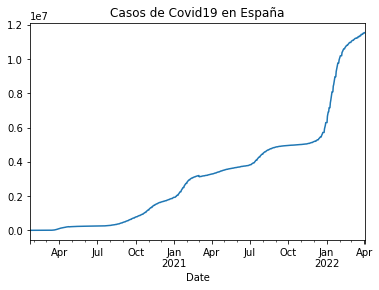

```python
df_es.set_index('Date')['Cases'].plot(title="Casos de Covid19 en España")
```

### Datos de Italia

Se repite el mismo proceso que se ha hecho hasta ahora, pero con otro país (Italia). Nos centramos solo en la representación visual de los datos:

[figure not shown]

```python
url_it = 'https://api.covid19api.com/country/italy/status/confirmed/live'
df_it = pd.read_json(url_it)
df_it.set_index('Date')['Cases'].plot()
```

## Comparación entre países

Una vez que se han visto diversos países por separados, es el momento de unir todos sus datos para poder compararlos y ver cómo han ido evolucionando sus casos confirmados de coronavirus a lo largo de un periodo temporal. Para ello, se crea una nueva variable por cada país que contenga solo los datos que se han ido necesitando y trabajando anteriormente: fecha y número de casos confirmados.

Se comparan estos dos países en un solo gráfico:

```python
casos_es = df_es.set_index('Date')['Cases']
casos_it = df_it.set_index('Date')['Cases']
```

Se concatenan los casos de los dos países en una misma tabla:

```python
vs = pd.concat([casos_es,casos_it],axis=1)
vs
```

| Date | Cases | Cases |
| --- | --- | --- |
| 2020-01-22 00:00:00+00:00 | 0 | 0 |
| 2020-01-23 00:00:00+00:00 | 0 | 0 |
| 2020-01-24 00:00:00+00:00 | 0 | 0 |
| 2020-01-25 00:00:00+00:00 | 0 | 0 |
| 2020-01-26 00:00:00+00:00 | 0 | 0 |
| ... | ... | ... |
| 2022-03-30 00:00:00+00:00 | 11508309 | 14567990 |
| 2022-03-31 00:00:00+00:00 | 11508309 | 14642354 |
| 2022-04-01 00:00:00+00:00 | 11551574 | 14719394 |
| 2022-04-02 00:00:00+00:00 | 11551574 | 14790806 |
| 2022-04-03 00:00:00+00:00 | 11551574 | 14845815 |

803 rows × 2 columns

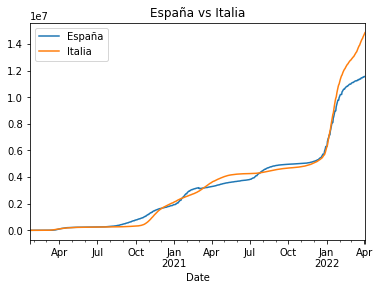

```python
vs.columns =['España', 'Italia']
vs.plot(title="España vs Italia")
```

Se exporta la nueva variable a un archivo separado por comas `(.csv)`, con la función `to_csv`.

```python
vs.to_csv('esvit.csv')
```

Se comprueba que el archivo se ha guardado ejecutando el comando bash `ls`:

```python
!ls
```

```
api-pandas-folium.ipynb  phyton-pruebas.ipynb		Shared_Resources
escit.png		 python-api-covid-pandas.ipynb	Untitled.ipynb
esvit.csv		 seaborn-data
```

Para guardar el gráfico como imagen PNG, tenemos que importar la librería *pyplot* de *matplotlib*, que ya se encuentra instalada. Se genera el gráfico de nuevo y con plt.savefig('nombre-grafico.png') se crea la imagen.

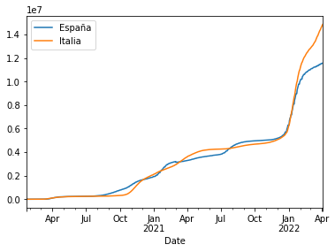

```python
import matplotlib.pyplot as plt
vs.plot()
plt.savefig('escit.png')
```